```python
from google.colab import drive
drive.mount('/content/drive')
```

# Predicting Scarcity

Provided with geographical data on wells and their local conditions, is it possible to mathematically model all recorded states and infer which well will face water scarcity within the year ahead? Features like depth of the well, water quality, municipality awareness, usage over time, etc. are readily availablefor tinkering with.

Note: *This notebook is for POC purposes and hence will not involve a lot of advanced mathematical modelling nor any fancy machine learning acrobatics. This is going to be as straight forward as it gets, though some discussion recommending further ideas and exploration should be expected.*

# Libraries

```python
# full package imports
import os
import warnings
import graphviz
import numpy as np
import pandas as pd
import seaborn as sns
import statsmodels.api as sm
import matplotlib.pyplot as plt

# module imports - plotting
from matplotlib.pylab import rcParams

# module imports - preprocessing
from scipy import stats
from sklearn.impute import SimpleImputer
from sklearn.preprocessing import StandardScaler, RobustScaler, MinMaxScaler, OneHotEncoder, LabelEncoder

# module imports - model setup
from sklearn.feature_selection import f_classif, RFE, SequentialFeatureSelector
from sklearn.model_selection import train_test_split, GridSearchCV

# module imports - model building
from sklearn.naive_bayes import CategoricalNB
from sklearn.discriminant_analysis import LinearDiscriminantAnalysis, QuadraticDiscriminantAnalysis
from sklearn.neural_network import MLPClassifier
from sklearn.svm import SVC
from xgboost import XGBClassifier, plot_importance
from sklearn.ensemble import RandomForestClassifier, VotingClassifier, StackingClassifier

# module imports - model evaluation
from sklearn.metrics import accuracy_score, roc_auc_score, plot_roc_curve

%matplotlib inline
warnings.filterwarnings("ignore")
os.getcwd()
```

```
'/content'
```

# Userdef functions

These functions were actually part of a custom python file but unfortunately there was some trouble importing it into colab. The functions have been copied and pasted here verbatim, so expect some duplication of imports.

Recommendation is to keep this cell folded for readability.

```python
import pandas as pd

from sklearn.decomposition import PCA
from sklearn.preprocessing import StandardScaler
from sklearn.model_selection import train_test_split
from sklearn.metrics import confusion_matrix, accuracy_score, classification_report, roc_auc_score, roc_curve, auc


# --------------------------------------------------------------------------- #
def data_viewer(data, max_threshold = 5):
    """
    Description:
    ---------------
    Basic EDA data viewing function displaying shape, head, tail, percentiled
    descriptive statistics and per-feature data types, null values and number
    of unique values. The distrubtion of unique values is also printed as a
    percentage of the total number of columns.

    Parameters:
    ---------------
    data [pd.DataFrame] = the dataframe to use.
    max_threshold [int] = the maximum number of unique values per feature to
                          use when scanning.
                          (default = 3)

    Returns:
    ---------------
    Nothing.
    """
    print("\n--------------------\nShape:\n--------------------")
    print(data.shape)

    print("\n--------------------\nHead:\n--------------------")
    with pd.option_context("display.max_columns", data.shape[1]):
        display(data.head(10))

    print("\n--------------------\nTail:\n--------------------")
    with pd.option_context("display.max_columns", data.shape[1]):
        display(data.tail(10))

    print("\n--------------------\nSummary:\n--------------------")
    dtype = data.dtypes.to_frame().transpose().set_axis(["dtype"])
    descr = data.describe(percentiles = [0.25, 0.50, 0.75, 0.90, 0.99],
                          include = "all")
    nullv = data.isnull().sum().to_frame().transpose().set_axis(["nulls"])
    nuniq = data.nunique().to_frame().transpose().set_axis(["uniques"])

    summary = pd.concat([dtype, descr, nullv, nuniq],
                        axis = 0, ignore_index = False)
    summary.rename(mapper = {"unique": "n_categories",
                             "top": "top_category",
                             "freq": "modal_categ"},
                   axis = "index",
                   inplace = True)

    with pd.option_context("display.float_format", "{:.1f}".format,
                           "display.max_columns", data.shape[1]):
        display(summary)

    print("\n--------------------\nIntrospection:\n--------------------")
    print(data.info())

    print("\n--------------------\nUniques:\n--------------------")
    for test in range(1, max_threshold, 1):
        ucols = (nuniq.transpose().uniques == test).sum()
        ratio = (ucols / len(data.columns)) * 100
        print("{0} columns have {1} unique value(s) [{2:.2f}%]"
              .format(ucols, test, ratio))

    print("\n====================================================\n")


# --------------------------------------------------------------------------- #
def u_count(data, u_val = 5, exact = False):
    """
    Description:
    ---------------
    A simple function to retrieve the features in a dataframe that have either
    exactly or up to u_val number of unique values.

    Parameters:
    ---------------
    data [pd.DataFrame] = the dataframe to use.
    u_val [int] = the number of unique values that a feature should have.
                  (default = 5)
    exact[bool] = if True, only features with exactly u_val number of unique
                  values will qualify.
                  (default = False)

    Returns:
    ---------------
    A list of names of all the features that qualified.
    """
    c_cols = []

    if exact is False:
        for col in data.columns[data.nunique() <= u_val]:
            c_cols.append(col)
    else:
        for col in data.columns[data.nunique() == u_val]:
            c_cols.append(col)

    return c_cols


# --------------------------------------------------------------------------- #
def u_skew(data, u_dist = 0.90):
    """
    Description:
    ---------------
    A function that retrieves the names of features in a dataframe that have an
    observation account for greater than or exactly u_dist percent. For example
    if a feature with 3 values is distributed as:
    a    0.9156
    b    0.0534
    c    0.0310
    the feature will qualify since its dominant value constitues 90% and above
    of the feature's data.

    Parameters:
    ---------------
    data [pd.DataFrame] = the dataframe to use.
    u_dist [int] = the percentage distribution that observations in a feature
                   should have. Should be between 0 and 1.
                   (default = 0.90)

    Returns:
    ---------------
    A list of names of all the features that qualified.
    """
    s_cols = []

    if u_dist < 0 or u_dist > 1:
        raise Exception("u_dist should be between 0 and 1.")
    else:
        for col in data.columns:
            if data[col].value_counts(normalize = True).values[0] >= u_dist:
                s_cols.append(col)

        return s_cols


# --------------------------------------------------------------------------- #
def get_contrib(data, against, minority = True):
    """
    A function that breaks down the contributors to a feature's minority or
    majority value. Useful in understanding the level of skew within a feature.

    If a dataframe feature has a skewed distribution (one value >=85%), instead
    of removing the column outright it helps to understand whether the dominant
    or minority value can be used to regress against or classify multiple other
    values in another feature (usually the target vector.) If so, removing such
    a skewed column would result in a direct loss of workable information.

    Parameters:
    ---------------
    data [pd.DataFrame / pd.Series] = the main dataframe to use.
    against [pd.Series] = the column within which to check contributors.
    minority [bool] = if False, use the feature's dominant value instead.
                      (default = True)

    Returns:
    ---------------
    Nothing.
```

```python
    Notes:
    ---------------
    1. The output text of Series.value_counts() is always terminated with the
    name of the series passed as "against." This kind of behaviour is inherent
    to pd.Series.value_counts().
    """
    if isinstance(data, pd.core.series.Series):
        # if we were sent in a single feature (pd.Series) we should concatenate
        # it into a dataframe along with the target feature and use the result.
        if minority is False:
            dom_val = data.value_counts().index[0]
        else:
            dom_val = data.value_counts().index[-1]

        col = data.name

        data = pd.concat([data, against], axis = 1)
        print("Column \"{}\" value \"{}\" has these contributors:"
              .format(col, dom_val))
        print("--------------------")
        print((data.loc[data[col] == dom_val])[against.name]
              .value_counts(normalize = True))

    else:
        # otherwise if we were sent in a dataframe (pd.DataFrame) we should
        # loop through all the columns and print out the target feature's value
        # counts corresponding to the dataframe column's dominant value.
        if against.name not in data.columns:
            data = pd.concat([data, against], axis = 1)

        for col in data.columns:
            if minority is False:
                dom_val = data[col].value_counts().index[0]
            else:
                dom_val = data[col].value_counts().index[-1]

            if col == against.name:
                continue
            print("Column \"{}\" value \"{}\" has these contributors:"
                  .format(col, dom_val))
            print("--------------------")
            print((data.loc[data[col] == dom_val])[against.name]
                  .value_counts(normalize = True), "\n")
            print("\n")


# --------------------------------------------------------------------------- #
def standard_pca(data, sum_eva = 5, standardised = True):
    """
    Description:
    ---------------
    A function to apply a PCA analysis to a given dataset. The sum of the first
    sum_eva components (default = 5) is also printed. The default assumption is
    that the data has already been standardised.

    Parameters:
    ---------------
    data [pd.DataFrame] = the dataframe to use.
    sum_eva [int] = the number of PCA components to sum.
                    (default = 5)
    standardised [bool] = if true, the data has been standardised already.
                          (default = True)

    Returns:
    ---------------
    data_pca = the PCA dataframe.
    pca_varatio = the pca_variance_ratio list.
    (if standardised = False)
    data_standard = the standardised dataframe.

    Notes:
    ---------------
    If standardised = False (i.e. the data hasn't been standardised), then
    StandardScaler() is used to standardise the data before running the PCA.
    PCA.
    """
    pca = PCA()

    if standardised == False:
        data_standard = StandardScaler().fit_transform(data)
        data_pca = pca.fit_transform(data_standard)
    else:
        data_pca = pca.fit_transform(data)

    pca_varatio = sorted(pca.explained_variance_ratio_, reverse = True)

    print("\n--------------------\nVariance Ratio:\n--------------------\n")
    print(pca_varatio)

    print("\n--------------------\nVariance Ratio sum:\n--------------------\n")
    print(sum(pca_varatio[0:sum_eva]))

    if standardised == False:
        return data_standard, data_pca, pca_varatio
    else:
        return data_pca, pca_varatio


# --------------------------------------------------------------------------- #
def prepare_data(X, y, split_size = 0.30, seed = 1337):
    """
    Description:
    ---------------
    A handy wrapper function around train_test_split with automatic stratifying
    against the target variable 'y'.

    Parameters:
    ---------------
    X [pd.dataFrame] = the dataframe containing independent features.
    y [pd.Series] = the target feature.
    split_size [int] = the desired size of the train/test split.
                       (default = 0.30)
    rand_seed [int] = the random seed to use when splitting.
                      (default = 1337)

    Returns:
    ---------------
    X_train, X_test, y_train, y_test.
    """
    X_train, X_test, y_train, y_test = train_test_split(X, y,
                                                        test_size = split_size,
                                                        random_state = seed,
                                                        stratify = y)
    print("X_train shape:", X_train.shape)
    print("X_test shape:", X_test.shape)
    return X_train, X_test, y_train, y_test


# --------------------------------------------------------------------------- #
def model_evaluation(actuals, predictions):
    """
    Description:
    ---------------
    A function to print out formatted evaluation metrics that gauge classifier
    models' performance. Uses sklearn.metrics' confusion_matrix(),
    classification_report() and accuracy_score().

    Parameters:
    ---------------
    actuals [pd.Series / np.array] = the target variable's values. This is of
                                     the form y_train and/or y_test; the actual
                                     data that you are trying to predict.
    predictions [pd.Series / np.array] = the predicted values for y. This is of
                                         the form pred_train and/or pred_test;
                                         the model's predictions for estimating
                                         the values of y_train/y_test.

    Returns:
    ---------------
    Nothing.
    """
    print('Confusion Matrix:')
    cmatrix = pd.DataFrame(confusion_matrix(actuals, predictions),
                           columns = ["Predicted NO", "Predicted YES"],
                           index = ["Actual NO", "Actual YES"])
    display(cmatrix)

    print('\nReport: ')
    print(classification_report(actuals, predictions))
```

```python
    print('\nAccuracy Score :', accuracy_score(actuals, predictions))
    print("-------------------------------------------------------------")


# --------------------------------------------------------------------------- #
```

# Begin

We're going to make a copy of our train and test data so that we don't taint the originals. In case anything untoward happens we can simply reset.

```python
df_train = pd.read_csv("/content/drive/MyDrive/Big-Data/Colab-Notebooks/29Aug22-RS-MiTH/train.csv")
df_test = pd.read_csv("/content/drive/MyDrive/Big-Data/Colab-Notebooks/29Aug22-RS-MiTH/test.csv")

dfcp_train = df_train.copy()
dfcp_test = df_test.copy()

data_viewer(dfcp_train)
```

```
--------------------
Shape:
--------------------
(44068, 34)

--------------------
Head:
--------------------
```

|  | Id | Amount_of_water | Gps_height | Waterpoint_type | Basin_name | Village | Regionname | Region_code | Wardname | District_code | Population | Public_meeting | Organization_funding | Organization_surveyed | Scheme_management | SchemeName | Permit | Company_installed | Management | Management_group | Extraction_type | Extraction_type_group | Extraction_type_class | Payment | Payment_type | Water_quality | Quality_group | Quantity | Quantity_group | … |
| --- | --- | --- | --- | --- | --- | --- | --- | --- | --- | --- | --- | --- | --- | --- | --- | --- | --- | --- | --- | --- | --- | --- | --- | --- | --- | --- | --- | --- | --- | --- |
| 0 | 56421 | 0.0 | 1555 | hand pump | basin3 | village8556 | region4 | 15 | ward500 | 3 | 650 | False | Org_543 | DataConsultantLtd | VWC | NaN | False | Iorg1388 | parastatal | parastatal | nira/tanira | nira/tanira | handpump | never pay | never pay | salty | salty | insufficient | insufficient | … |
| 1 | 21324 | 500.0 | 857 | communal standpipe multiple | basin7 | village7372 | region5 | 10 | ward1800 | 5 | 600 | False | Org_1233 | DataConsultantLtd | VWC | SCM1950 | True | Iorg1310 | parastatal | parastatal | gravity | gravity | gravity | pay monthly | monthly | soft | good | insufficient | insufficient | … |
| 2 | 74 | 0.0 | 0 | communal standpipe | basin1 | village9460 | region6 | 17 | ward883 | 3 | 0 | True | Org_1409 | DataConsultantLtd | VWC | NaN | True | Iorg1510 | vwc | user-group | windmill | wind-powered | wind-powered | never pay | never pay | soft | good | insufficient | insufficient | … |
| 3 | 74038 | 0.0 | 0 | other | basin5 | village13878 | region13 | 18 | ward1505 | 7 | 0 | True | Org_1460 | DataConsultantLtd | VWC | NaN | True | Iorg1388 | vwc | user-group | other | other | other | never pay | never pay | soft | good | insufficient | insufficient | … |
| 4 | 29929 | 0.0 | 0 | hand pump | basin4 | village5192 | region6 | 14 | ward942 | 4 | 0 | True | Iorg788 | DataConsultantLtd | VWC | NaN | True | Iorg788 | vwc | user-group | afridev | afridev | handpump | never pay | never pay | soft | good | enough | enough | … |
| 5 | 42776 | 0.0 | 1728 | communal standpipe | basin2 | village12464 | region12 | 11 | ward1829 | 5 | 108 | True | Iorg2054 | DataConsultantLtd | VWC | SCM875 | False | Iorg2054 | vwc | user-group | gravity | gravity | gravity | pay when scheme fails | on failure | soft | good | enough | enough | … |
| 6 | 40605 | 20.0 | 1729 | communal standpipe | basin1 | village2746 | region17 | 21 | ward1243 | 3 | 192 | True | Iorg84 | DataConsultantLtd | VWC | SCM1034 | True | Iorg84 | vwc | user-group | submersible | submersible | submersible | pay per bucket | per bucket | soft | good | enough | enough | … |
| 7 | 27119 | 0.0 | 415 | communal standpipe | basin9 | village14908 | region2 | 5 | ward2083 | 6 | 50 | True | Org_298 | DataConsultantLtd | VWC | SCM2662 | True | Iorg504 | vwc | user-group | gravity | gravity | gravity | never pay | never pay | soft | good | enough | enough | … |
| 8 | 26863 | 0.0 | 405 | other | basin8 | village18695 | region16 | 8 | ward1569 | 3 | 60 | True | Org_135 | DataConsultantLtd | VWC | NaN | False | Iorg1449 | vwc | user-group | other | other | other | never pay | never pay | salty | salty | dry | dry | … |
| 9 | 21239 | 0.0 | 1143 | hand pump | basin5 | village17784 | region18 | 20 | ward552 | 4 | 200 | True | Org_1460 | DataConsultantLtd | WUG | NaN | False | Iorg1388 | wug | user-group | other | other | other | never pay | never pay | salty | salty | dry | dry | … |

```
--------------------
Tail:
--------------------
```

|  | Id | Amount_of_water | Gps_height | Waterpoint_type | Basin_name | Village | Regionname | Region_code | Wardname | District_code | Population | Public_meeting | Organization_funding | Organization_surveyed | Scheme_management | SchemeName | Permit | Company_installed | Management | Management_group | Extraction_type | Extraction_type_group | Extraction_type_class | Payment | Payment_type | Water_quality | Quality_group | Quantity | Quantity_group | … |
| --- | --- | --- | --- | --- | --- | --- | --- | --- | --- | --- | --- | --- | --- | --- | --- | --- | --- | --- | --- | --- | --- | --- | --- | --- | --- | --- | --- | --- | --- | --- |
| 44058 | 57443 | 0.0 | 1770 | communal standpipe | basin6 | village16785 | region9 | 4 | ward819 | 1 | 1 | True | Iorg690 | DataConsultantLtd | VWC | SCM1683 | True | Iorg690 | vwc | user-group | gravity | gravity | gravity | never pay | never pay | soft | good | enough | enough | … |
| 44059 | 17100 | 0.0 | 706 | communal standpipe | basin2 | village18845 | region12 | 11 | ward1263 | 5 | 41 | True | Iorg89 | DataConsultantLtd | VWC | SCM631 | False | Iorg89 | vwc | user-group | gravity | gravity | gravity | pay when scheme fails | on failure | soft | good | enough | enough | … |
| 44060 | 6307 | 0.0 | 770 | communal standpipe | basin9 | village11664 | region2 | 5 | ward1542 | 6 | 20 | True | Org_1409 | DataConsultantLtd | VWC | SCM1268 | True | Iorg504 | vwc | user-group | gravity | gravity | gravity | never pay | never pay | soft | good | insufficient | insufficient | … |
| 44061 | 53682 | 0.0 | 0 | hand pump | basin3 | village10164 | region19 | 12 | ward349 | 6 | 0 | True | Org_1653 | DataConsultantLtd | VWC | NaN | False | Iorg1793 | vwc | user-group | nira/tanira | nira/tanira | handpump | pay when scheme fails | on failure | soft | good | enough | enough | … |
| 44062 | 35383 | 0.0 | 504 | communal standpipe | basin8 | village3373 | region16 | 80 | ward2092 | 43 | 350 | False | Org_1155 | DataConsultantLtd | VWC | SCM2598 | True | Iorg1189 | vwc | user-group | ksb | submersible | submersible | never pay | never pay | soft | good | dry | dry | … |
| 44063 | 33555 | 0.0 | 0 | improved spring | basin5 | village16282 | region13 | 18 | ward1422 | 2 | 0 | True | Iorg1388 | DataConsultantLtd | VWC | NaN | True | Iorg1388 | vwc | user-group | gravity | gravity | gravity | never pay | never pay | soft | good | insufficient | insufficient | … |
| 44064 | 17775 | 0.0 | 618 | hand pump | basin8 | village10061 | region5 | 10 | ward2060 | 1 | 1 | True | Org_761 | DataConsultantLtd | VWC | NaN | False | Iorg694 | vwc | user-group | other - swn 81 | other handpump | handpump | pay per bucket | per bucket | soft | good | enough | enough | … |
| 44065 | 34200 | 0.0 | 1582 | communal standpipe | basin7 | village9791 | region12 | 11 | ward1897 | 4 | 80 | True | Org_1409 | DataConsultantLtd | VWC | SCM171 | False | Iorg1388 | vwc | user-group | gravity | gravity | gravity | never pay | never pay | soft | good | enough | enough | … |
| 44066 | 17012 | 200.0 | 629 | communal standpipe | basin6 | village12243 | region15 | 3 | ward1248 | 3 | 120 | True | Org_1656 | DataConsultantLtd | Water authority | SCM136 | True | Iorg1797 | vwc | user-group | gravity | gravity | gravity | pay monthly | monthly | soft | good | enough | enough | … |
| 44067 | 28533 | 0.0 | 1512 | hand pump | basin1 | village2454 | region7 | 13 | ward1948 | 4 | 1 | True | Org_660 | DataConsultantLtd | WUG | NaN | True | Iorg610 | wug | user-group | india mark ii | india mark ii | handpump | never pay | never pay | soft | good | seasonal | seasonal | … |

```
--------------------
Summary:
--------------------
```

|  | Id | Amount_of_water | Gps_height | Waterpoint_type | Basin_name | Village | Regionname | Region_code | Wardname | District_code | Population | Public_meeting | Organization_funding | Organization_surveyed | Scheme_management | SchemeName | Permit | Company_installed | Management | Management_group | Extraction_type | Extraction_type_group | Extraction_type_class | Payment | Payment_type | Water_quality | Quality_group | Quantity | Quantity_group | … |
| --- | --- | --- | --- | --- | --- | --- | --- | --- | --- | --- | --- | --- | --- | --- | --- | --- | --- | --- | --- | --- | --- | --- | --- | --- | --- | --- | --- | --- | --- | --- |
| dtype | int64 | float64 | int64 | object | object | object | object | int64 | object | int64 | int64 | object | object | object | object | object | object | object | object | object | object | object | object | object | object | object | object | object | object | … |
| count | 44068.0 | 44068.0 | 44068.0 | 44068 | 44068 | 44068 | 44068 | 44068.0 | 44068 | 44068.0 | 44068.0 | 41543 | 41468 | 44068 | 41138 | 23117 | 41841 | 41465 | 44068 | 44068 | 44068 | 44068 | 44068 | 44068 | 44068 | 44068 | 44068 | 44068 | 44068 | … |
| n_categories | NaN | NaN | NaN | 7 | 9 | 16471 | 21 | NaN | 2087 | NaN | NaN | 2 | 2380 | 1 | 12 | 2505 | 2 | 1873 | 12 | 5 | 18 | 13 | 7 | 7 | 7 | 8 | 6 | 5 | 5 | … |
| top_category | NaN | NaN | NaN | communal standpipe | basin5 | village18166 | region12 | NaN | ward1290 | NaN | NaN | True | Iorg1388 | DataConsultantLtd | VWC | SCM425 | True | Iorg1388 | vwc | user-group | gravity | gravity | gravity | never pay | never pay | soft | good | enough | enough | … |
| modal_categ | NaN | NaN | NaN | 21085 | 7397 | 382 | 4190 | NaN | 240 | NaN | NaN | 37800 | 5246 | 44068 | 27563 | 485 | 28970 | 12659 | 30173 | 38865 | 19302 | 19302 | 19302 | 18752 | 18752 | 37551 | 37551 | 24610 | 24610 | … |
| mean | 37092.5 | 329.8 | 674.3 | NaN | NaN | NaN | NaN | 15.2 | NaN | 5.7 | 179.8 | NaN | NaN | NaN | NaN | NaN | NaN | NaN | NaN | NaN | NaN | NaN | NaN | NaN | NaN | NaN | NaN | NaN | NaN | … |
| std | 21490.9 | 3127.6 | 698.1 | NaN | NaN | NaN | NaN | 17.6 | NaN | 9.7 | 473.6 | NaN | NaN | NaN | NaN | NaN | NaN | NaN | NaN | NaN | NaN | NaN | NaN | NaN | NaN | NaN | NaN | NaN | NaN | … |
| min | 0.0 | 0.0 | -63.0 | NaN | NaN | NaN | NaN | 1.0 | NaN | 0.0 | 0.0 | NaN | NaN | NaN | NaN | NaN | NaN | NaN | NaN | NaN | NaN | NaN | NaN | NaN | NaN | NaN | NaN | NaN | NaN | … |
| 25% | 18363.2 | 0.0 | 0.0 | NaN | NaN | NaN | NaN | 5.0 | NaN | 2.0 | 0.0 | NaN | NaN | NaN | NaN | NaN | NaN | NaN | NaN | NaN | NaN | NaN | NaN | NaN | NaN | NaN | NaN | NaN | NaN | … |
| 50% | 37021.5 | 0.0 | 370.0 | NaN | NaN | NaN | NaN | 12.0 | NaN | 3.0 | 25.0 | NaN | NaN | NaN | NaN | NaN | NaN | NaN | NaN | NaN | NaN | NaN | NaN | NaN | NaN | NaN | NaN | NaN | NaN | … |
| 75% | 55685.2 | 20.0 | 1327.0 | NaN | NaN | NaN | NaN | 17.0 | NaN | 5.0 | 211.0 | NaN | NaN | NaN | NaN | NaN | NaN | NaN | NaN | NaN | NaN | NaN | NaN | NaN | NaN | NaN | NaN | NaN | NaN | … |
| 90% | 66859.3 | 500.0 | 1656.0 | NaN | NaN | NaN | NaN | 20.0 | NaN | 7.0 | 450.0 | NaN | NaN | NaN | NaN | NaN | NaN | NaN | NaN | NaN | NaN | NaN | NaN | NaN | NaN | NaN | NaN | NaN | NaN | … |
| 99% | 73516.3 | 5000.0 | 2149.0 | NaN | NaN | NaN | NaN | 90.0 | NaN | 53.0 | 2000.0 | NaN | NaN | NaN | NaN | NaN | NaN | NaN | NaN | NaN | NaN | NaN | NaN | NaN | NaN | NaN | NaN | NaN | NaN | … |
| max | 74242.0 | 350000.0 | 2628.0 | NaN | NaN | NaN | NaN | 99.0 | NaN | 80.0 | 30500.0 | NaN | NaN | NaN | NaN | NaN | NaN | NaN | NaN | NaN | NaN | NaN | NaN | NaN | NaN | NaN | NaN | NaN | NaN | … |
| nulls | 0 | 0 | 0 | 0 | 0 | 0 | 0 | 0 | 0 | 0 | 0 | 2525 | 2600 | 0 | 2930 | 20951 | 2227 | 2603 | 0 | 0 | 0 | 0 | 0 | 0 | 0 | 0 | 0 | 0 | 0 | … |
| uniques | 44068 | 91 | 2389 | 7 | 9 | 16471 | 21 | 27 | 2087 | 20 | 955 | 2 | 2380 | 1 | 12 | 2505 | 2 | 1873 | 12 | 5 | 18 | 13 | 7 | 7 | 7 | 8 | 6 | 5 | 5 | … |

```
--------------------
Introspection:
--------------------
<class 'pandas.core.frame.DataFrame'>
RangeIndex: 44068 entries, 0 to 44067
Data columns (total 34 columns):
 #   Column                 Non-Null Count  Dtype
---  ------                 --------------  -----
 0   Id                     44068 non-null  int64
 1   Amount_of_water        44068 non-null  float64
 2   Gps_height             44068 non-null  int64
 3   Waterpoint_type        44068 non-null  object
 4   Basin_name             44068 non-null  object
 5   Village                44068 non-null  object
 6   Regionname             44068 non-null  object
 7   Region_code            44068 non-null  int64
 8   Wardname               44068 non-null  object
 9   District_code          44068 non-null  int64
 10  Population             44068 non-null  int64
 11  Public_meeting         41543 non-null  object
 12  Organization_funding   41468 non-null  object
 13  Organization_surveyed  44068 non-null  object
 14  Scheme_management      41138 non-null  object
 15  SchemeName             23117 non-null  object
 16  Permit                 41841 non-null  object
 17  Company_installed      41465 non-null  object
 18  Management             44068 non-null  object
 19  Management_group       44068 non-null  object
 20  Extraction_type        44068 non-null  object
 21  Extraction_type_group  44068 non-null  object
 22  Extraction_type_class  44068 non-null  object
 23  Payment                44068 non-null  object
 24  Payment_type           44068 non-null  object
 25  Water_quality          44068 non-null  object
 26  Quality_group          44068 non-null  object
 27  Quantity               44068 non-null  object
 28  Quantity_group         44068 non-null  object
 29  Source                 44068 non-null  object
 30  Source_type            44068 non-null  object
 31  Source_class           44068 non-null  object
 32  Waterpoint_type_group  44068 non-null  object
 33  Status                 44068 non-null  int64
dtypes: float64(1), int64(6), object(27)
memory usage: 11.4+ MB
None

--------------------
Uniques:
--------------------
1 columns have 1 unique value(s) [2.94%]
3 columns have 2 unique value(s) [8.82%]
1 columns have 3 unique value(s) [2.94%]
0 columns have 4 unique value(s) [0.00%]

====================================================
```

Let's quickly check our target and see whether we have an imbalance in occurrence. If we do, we'll need to strategise a little more. We'll also drop our ID Column because we don't need it for training.

```python
dfcp_train.drop("Id", axis = 1, inplace = True)
dfcp_train["Status"].value_counts(normalize = True)
```

```
1    0.58564
0    0.41436
Name: Status, dtype: float64
```

Our target is balanced! Now most of our data is categorical and so are all of our NaNs. If this notebook were oriented differently, we could leverage some seriously wicked pieces of machine learning math to impute these null values; keeping it simple however means we'll just fill them up with their modal categories and call it a day. Some alternative approaches that would work pretty well here given our feature set include geophysical imputation using location data with haversine distances, categorical regression modelling, embedding existing values and then performing tensor-based expectation maximisation, etc.

We'll inspect our numerical features for feature interactions before moving onto handling our categoricals. Notice that we have columns like `Region_code` and `DistrictCode` that are really categories. Therefore we can't shift and scale these - they should probably be left as is.

## Numerical preprocessing

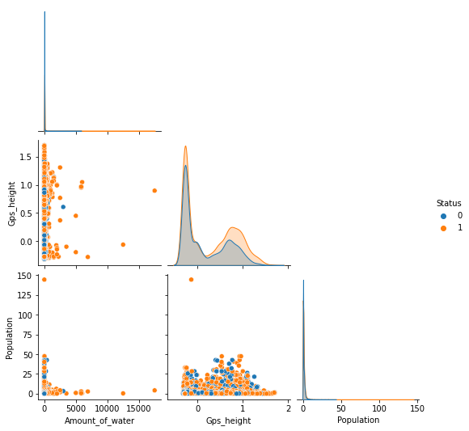

```python
# first we want to select only our numerical columns which we can do by ignoring
# anything non-numeric. This also lets us pull out our floats in one fell swoop
# and will also retain our target feature for colouration purposes.

num_cols = dfcp_train.select_dtypes(exclude = "object")
tfm_cols = num_cols.drop(["Region_code", "District_code", "Status"], axis = 1)

# We will need to scale our data before visualising it. We can use the median &
# quantiles because it's robust to skew: I'm picking the most reservist approach
# to scaling so that we can visualise our distributions before we know what our
# distributions truly look like. We don't want to scale our target feature so
# we'll drop that before applying the scaling. Note that scaling doesn't affect
# a data's distribution at all.
rob = RobustScaler()
pp_train = rob.fit_transform(dfcp_train[tfm_cols.columns])
pp_train = pd.DataFrame(data = pp_train, columns = tfm_cols.columns)
pp_train = pd.concat([pp_train, dfcp_train["Status"]], axis = 1)

sns.pairplot(data = pp_train, corner = True, hue = "Status")

# We should remove our temporary pairplot dataframe to save memory.
del(pp_train)
```

No linear separability nor feature interactions in 2D which almost certainly means all effective information is contained within our categoricals. We also have extreme amounts of skew; we can try log transforming our numerical features to get them closer to normality. Let's get some more perspectives on this data before we do anything to it.

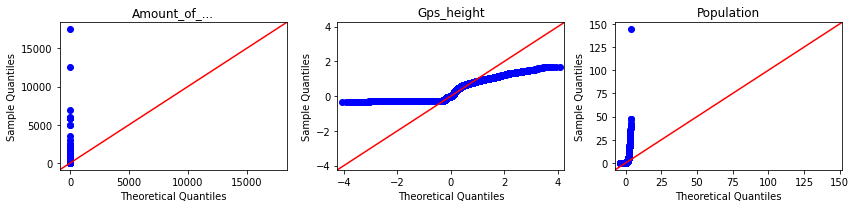

```python
qq_train = rob.transform(dfcp_train[tfm_cols.columns])
qq_train = pd.DataFrame(data = qq_train, columns = tfm_cols.columns)

# Some of our column names are very long, we can truncate them like so (MCVE):
# ls = "longstring"
# print(ls[:5] + "..." if len(ls) > 5 else ls)
# > longs...

fig, axes = plt.subplots(ncols=3, nrows=1, figsize=(12, 3))

for col, ax in zip(qq_train.columns, np.ravel(axes)):
    sm.qqplot(qq_train[col], line = "45", ax = ax)
    ax.set_title((col[0:10] + "..." if len(col) > 10 else col))

plt.tight_layout()
plt.show()

# We should remove our temporary pairplot dataframe to save memory.
del(qq_train)
```

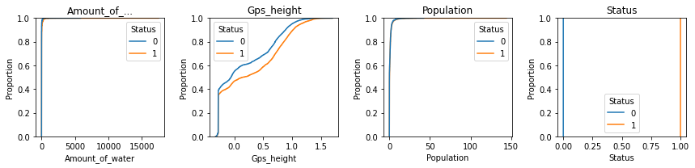

```python
ecdf_train = rob.transform(dfcp_train[tfm_cols.columns])
ecdf_train = pd.DataFrame(data = ecdf_train, columns = tfm_cols.columns)
ecdf_train = pd.concat([ecdf_train, dfcp_train["Status"]], axis = 1)

# Some of our column names are very long, we can truncate them like so (MCVE):
# ls = "longstring"
# print(ls[:5] + "..." if len(ls) > 5 else ls)
# > longs...

fig, axes = plt.subplots(ncols=4, nrows=1, figsize=(12, 3))

for col, ax in zip(ecdf_train.columns, np.ravel(axes)):
    sns.ecdfplot(data = ecdf_train, x = ecdf_train[col], hue = "Status",
                 log_scale = False, ax = ax)
    ax.set_title((col[0:10] + "..." if len(col) > 10 else col))

plt.tight_layout()
plt.show()

# We should remove our temporary pairplot dataframe to save memory.
del(ecdf_train)
```

```python
print("Before transforming:")
display(tfm_cols)

print("\n\nAfter transforming:\n")
log_cols = np.log(tfm_cols + 1)
log_cols = pd.concat([log_cols, num_cols[["Region_code", "District_code", "Status"]]], axis = 1)
display(log_cols)
```

```
Before transforming:
```

|  | Amount_of_water | Gps_height | Population |
| --- | --- | --- | --- |
| 0 | 0.0 | 1555 | 650 |
| 1 | 500.0 | 857 | 600 |
| 2 | 0.0 | 0 | 0 |
| 3 | 0.0 | 0 | 0 |
| 4 | 0.0 | 0 | 0 |
| ... | ... | ... | ... |
| 44063 | 0.0 | 0 | 0 |
| 44064 | 0.0 | 618 | 1 |
| 44065 | 0.0 | 1582 | 80 |
| 44066 | 200.0 | 629 | 120 |
| 44067 | 0.0 | 1512 | 1 |

44068 rows × 3 columns

```
After transforming:
```

|  | Amount_of_water | Gps_height | Population | Region_code | District_code | Status |
| --- | --- | --- | --- | --- | --- | --- |
| 0 | 0.000000 | 7.349874 | 6.478510 | 15 | 3 | 0 |
| 1 | 6.216606 | 6.754604 | 6.398595 | 10 | 5 | 0 |
| 2 | 0.000000 | 0.000000 | 0.000000 | 17 | 3 | 0 |
| 3 | 0.000000 | 0.000000 | 0.000000 | 18 | 7 | 0 |
| 4 | 0.000000 | 0.000000 | 0.000000 | 14 | 4 | 1 |
| ... | ... | ... | ... | ... | ... | ... |
| 44063 | 0.000000 | 0.000000 | 0.000000 | 18 | 2 | 1 |
| 44064 | 0.000000 | 6.428105 | 0.693147 | 10 | 1 | 0 |
| 44065 | 0.000000 | 7.367077 | 4.394449 | 11 | 4 | 0 |
| 44066 | 5.303305 | 6.445720 | 4.795791 | 3 | 3 | 1 |
| 44067 | 0.000000 | 7.321850 | 0.693147 | 13 | 4 | 0 |

44068 rows × 6 columns

```python
log_cols.isnull().sum()
```

```
Amount_of_water       0
Gps_height         1143
Population            0
Region_code           0
District_code         0
Status                0
dtype: int64
```

```python
log_cols["Gps_height"] = np.nan_to_num(x = log_cols["Gps_height"], nan = 1.0,
                                       copy = False, neginf = 0.0)

print(log_cols.isnull().sum(), "\n")
display(log_cols)
```

```
Amount_of_water    0
Gps_height         0
Population         0
Region_code        0
District_code      0
Status             0
dtype: int64
```

|  | Amount_of_water | Gps_height | Population | Region_code | District_code | Status |
| --- | --- | --- | --- | --- | --- | --- |
| 0 | 0.000000 | 7.349874 | 6.478510 | 15 | 3 | 0 |
| 1 | 6.216606 | 6.754604 | 6.398595 | 10 | 5 | 0 |
| 2 | 0.000000 | 0.000000 | 0.000000 | 17 | 3 | 0 |
| 3 | 0.000000 | 0.000000 | 0.000000 | 18 | 7 | 0 |
| 4 | 0.000000 | 0.000000 | 0.000000 | 14 | 4 | 1 |
| ... | ... | ... | ... | ... | ... | ... |
| 44063 | 0.000000 | 0.000000 | 0.000000 | 18 | 2 | 1 |
| 44064 | 0.000000 | 6.428105 | 0.693147 | 10 | 1 | 0 |
| 44065 | 0.000000 | 7.367077 | 4.394449 | 11 | 4 | 0 |
| 44066 | 5.303305 | 6.445720 | 4.795791 | 3 | 3 | 1 |
| 44067 | 0.000000 | 7.321850 | 0.693147 | 13 | 4 | 0 |

44068 rows × 6 columns

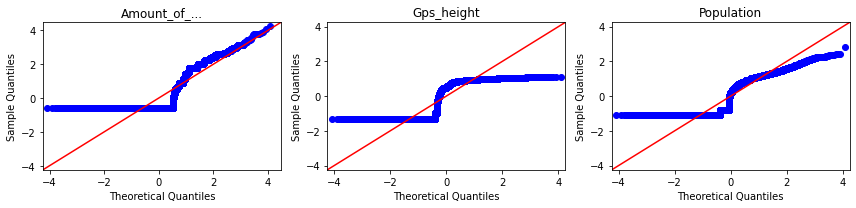

```python
std = StandardScaler()
qq_train = std.fit_transform(log_cols[tfm_cols.columns])
qq_train = pd.DataFrame(data = qq_train, columns = tfm_cols.columns)

fig, axes = plt.subplots(ncols=3, nrows=1, figsize=(12, 3))

for col, ax in zip(qq_train.columns, np.ravel(axes)):
    sm.qqplot(qq_train[col], line = "45", ax = ax)
    ax.set_title((col[0:10] + "..." if len(col) > 10 else col))

plt.tight_layout()
plt.show()

# We should remove our temporary pairplot dataframe to save memory.
del(qq_train)
```

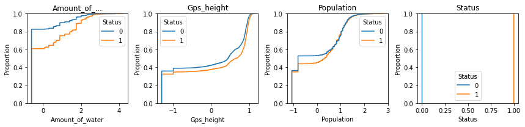

```python
ecdf_train = std.transform(log_cols[tfm_cols.columns])
ecdf_train = pd.DataFrame(data = ecdf_train, columns = tfm_cols.columns)
ecdf_train = pd.concat([ecdf_train, num_cols["Status"]], axis = 1)

# Some of our column names are very long, we can truncate them like so (MCVE):
# ls = "longstring"
# print(ls[:5] + "..." if len(ls) > 5 else ls)
# > longs...

fig, axes = plt.subplots(ncols=4, nrows=1, figsize=(12, 3))

for col, ax in zip(ecdf_train.columns, np.ravel(axes)):
    sns.ecdfplot(data = ecdf_train, x = ecdf_train[col], hue = "Status",
                 log_scale = False, ax = ax)
    ax.set_title((col[0:10] + "..." if len(col) > 10 else col))

plt.tight_layout()
plt.show()

# We should remove our temporary pairplot dataframe to save memory.
del(ecdf_train)
```

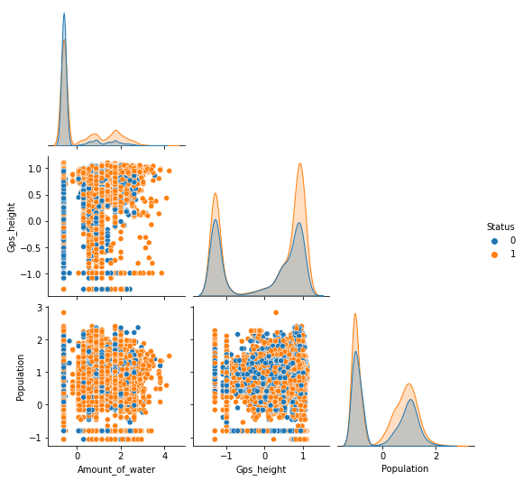

```python
pp_train = std.transform(log_cols[tfm_cols.columns])
pp_train = pd.DataFrame(data = pp_train, columns = tfm_cols.columns)
pp_train = pd.concat([pp_train, num_cols["Status"]], axis = 1)

sns.pairplot(data = pp_train, corner = True, hue = "Status")
del(pp_train)
```

Definitely better and much more informative: all our numerical features are bimodal except for `amount_of_water`, which is still heavily skewed. This is very good, because it means while our numerical features might now contain good separation power, combining them with our categoricals will give us some pretty fantastic results. Nevertheless, let's have a quick run wth LDA and see how helpful these features are.

### Numerical Classification: test run

```python
X_train_num, X_test_num, y_train_num, y_test_num = prepare_data(X = log_cols.drop("Status", axis = 1),
                                                                y = log_cols["Status"])
```

```
X_train shape: (30847, 5)
X_test shape: (13221, 5)
```

```
CPU times: user 466 ms, sys: 352 ms, total: 818 ms
Wall time: 451 ms

### GRID SEARCH: LINEAR DISCRIMINANT ANALYSIS ###
-------------------------
Best estimator:	 LinearDiscriminantAnalysis(shrinkage='auto', solver='lsqr')
Best score:		 0.6108534831842067 	(61.09%)
Accuracy train:	 0.6107563134178364 	(61.08%)
Accuracy test:	 0.6106194690265486 	(61.06%)


Confusion Matrix:
```

|  | Predicted NO | Predicted YES |
| --- | --- | --- |
| Actual NO | 1190 | 4288 |
| Actual YES | 860 | 6883 |

```
Report:
              precision    recall  f1-score   support

           0       0.58      0.22      0.32      5478
           1       0.62      0.89      0.73      7743

    accuracy                           0.61     13221
   macro avg       0.60      0.55      0.52     13221
weighted avg       0.60      0.61      0.56     13221


Accuracy Score : 0.6106194690265486
-------------------------------------------------------------
Receiver Operating Characteristics:

ROC AUC score:	 0.5530822525776382
```

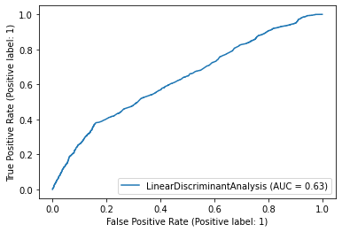

```python
# build our grid
lda_params = [{"solver": ["svd", "lsqr", "eigen"]}]
lda = LinearDiscriminantAnalysis(shrinkage = "auto")

gscv_lda = GridSearchCV(estimator = lda,
                        param_grid = lda_params,
                        n_jobs = -3,
                        cv = 5,
                        scoring = "accuracy")

# fit it to our training data (the splits)
%time gscv_lda.fit(X = X_train_num, y = y_train_num)
lda_m1 = gscv_lda.best_estimator_
prtr_lda1 = lda_m1.predict(X_train_num)
prte_lda1 = lda_m1.predict(X_test_num)

# get our best performing model and format our split results
print("\n### GRID SEARCH: LINEAR DISCRIMINANT ANALYSIS ###")
print("-------------------------")
print("Best estimator:\t", lda_m1, "\nBest score:\t\t", gscv_lda.best_score_,
      "\t({:.2f}%)".format(gscv_lda.best_score_ * 100))
print("Accuracy train:\t", accuracy_score(y_train_num, prtr_lda1),
      "\t({:.2f}%)".format(accuracy_score(y_train_num, prtr_lda1) * 100))
print("Accuracy test:\t", accuracy_score(y_test_num, prte_lda1),
      "\t({:.2f}%)".format(accuracy_score(y_test_num, prte_lda1) * 100))

# print some more detailed metrics to see how our model actually performed
print("\n")
model_evaluation(actuals = y_test_num, predictions = prte_lda1)

print("Receiver Operating Characteristics:")
print("\nROC AUC score:\t", roc_auc_score(y_true = y_test_num,
                                          y_score = prte_lda1))
plot_roc_curve(estimator = lda_m1, X = X_test_num, y = y_test_num);
```

## Categorical preprocessing

```python
cat_cols = dfcp_train.select_dtypes(include = "object")

for col in cat_cols.columns:
    print(cat_cols[col].value_counts(normalize = True))
    print("\n")
```

```
communal standpipe             0.478465
hand pump                      0.299469
other                          0.109127
communal standpipe multiple    0.097940
improved spring                0.012594
cattle trough                  0.002247
dam                            0.000159
Name: Waterpoint_type, dtype: float64


basin5    0.167854
basin6    0.152673
basin7    0.137969
basin1    0.130934
basin9    0.103885
basin4    0.102705
basin2    0.088273
basin8    0.075066
basin3    0.040642
Name: Basin_name, dtype: float64


village18166    0.008668
village8556     0.008464
village17891    0.008192
village1        0.006558
village14666    0.005832
                  ...
village4275     0.000023
village8121     0.000023
village8857     0.000023
village15281    0.000023
village3373     0.000023
Name: Village, Length: 16471, dtype: float64


region12    0.095080
region6     0.077948
region19    0.076178
region15    0.073024
```

[output cut: 252 more lines]

```


groundwater    0.780249
surface        0.214782
unknown        0.004970
Name: Source_class, dtype: float64


communal standpipe    0.576405
hand pump             0.299469
other                 0.109127
improved spring       0.012594
cattle trough         0.002247
dam                   0.000159
Name: Waterpoint_type_group, dtype: float64
```

We have a single feature with only one item throughout its length: `Organization_surveyed`. This can be removed WLOG because such features are heavily correlated with all others and with every target class possible, meaning they do not contribute anything. We also have 2 features that seem to be skewed: `management_group` and `public_meeting`. The dominant values in these features constitutes over 85% of all its values. We *could* go ahead and hack these out as well, but we need to consider the minorities: do their less impressionable values contribute to a significant class variance? In other words, can the minority values help classify a considerable percentage of observations? If they do, we can't remove the features because their minorities contribute to separability.

```python
cat_cols.drop("Organization_surveyed", axis = 1)
sk_cols = ["Management_group", "Public_meeting"]

get_contrib(cat_cols[sk_cols], dfcp_train["Status"])
```

```
Column "Management_group" value "unknown" has these contributors:
--------------------
0    0.572447
1    0.427553
Name: Status, dtype: float64



Column "Public_meeting" value "False" has these contributors:
--------------------
0    0.528186
1    0.471814
Name: Status, dtype: float64
```

Looks like our skewed features' minority values contribute to a very balanced amount of target classes, so removing them will degrade performance and contribute to bias. A couple of other things:

1. we have some categorical features that are exact duplicates of another. We might need to iterate through all of them to find out which ones are like that *before* encoding them.
2. we have a few features with only 2 values. We should see what these binomial features are because we might not have to label encode them at all.

```python
b_cols = u_count(dfcp_train, 2, exact = True)
dfcp_train[b_cols]
```

|  | Public_meeting | Permit | Status |
| --- | --- | --- | --- |
| 0 | False | False | 0 |
| 1 | False | True | 0 |
| 2 | True | True | 0 |
| 3 | True | True | 0 |
| 4 | True | True | 1 |
| ... | ... | ... | ... |
| 44063 | True | True | 1 |
| 44064 | True | False | 0 |
| 44065 | True | False | 0 |
| 44066 | True | True | 1 |
| 44067 | True | True | 0 |

44068 rows × 3 columns

```python
# This is a MCVE of what we're about to do on our actual df_binom dataframe.

# x = [1, 2, 3, 4, 5]
# y = [1, 2, 3, 4, 5]
# ff = pd.DataFrame()
# ff['x'] = x
# ff['y'] = y
# sum(ff['x'] == ff['y']) == len(ff['x'])

# We're looking for columns that have exactly the same values as another column
# does. This means that every value in column A has to match column B, in which
# case we can remove either A or B. One way to do this is using booleans: if
# the value in col(A) == col(B), the element check will return True. If the sum
# of all the booleans == the length of the column, we have an exact match.

# We could do it using a dataframe too, like so:

# col_arr = []
# match_df = pd.DataFrame(columns = df_binom.columns, index = df_binom.columns)
# for col in df_binom.columns:
#     for subcol in df_binom.columns:
#         if col == subcol:
#             col_arr.append(1)
#         else:
#             col_arr.append(sum(df_binom[col] == df_binom[subcol]))
#     match_df[col] = col_arr
#     col_arr.clear()
# with pd.option_context("display.max_columns", df_binom.shape[1],
#                        "display.max_rows", df_binom.shape[0]):
#    display(match_df)

# but this approach makes it quite difficult to figure out which columns are
# replicated by which other columns especially if one column matches up with
# more than 2 other ones. Note that this entire explanation was lifted from a
# different dataset and repurposed for categorical variables. The sum() op might
# not work directly, so a relatively simple for-loop should be adequate enough:

for col in cat_cols.columns:
    for subcol in cat_cols.columns:
        count = 0

        if col == subcol:
            continue
        else:
            for iter8 in range(0, len(cat_cols[col].values)):
                if (cat_cols[col].values[iter8] == cat_cols[subcol].values[iter8]):
                    count += 1
                else:
                    continue

    if count == len(cat_cols[col].values):
        print(col, "100% matches with", subcol)
        print("\n")

%time
```

```
CPU times: user 3 µs, sys: 0 ns, total: 3 µs
Wall time: 7.15 µs
```

Interesting, none of our categoricals *directly* overlap with another, but the reasons for suspcicion remain. If we go through the feature names and head values with a fine toothed comb along with reading the attribute descriptions, we should see some immense overlap that's seriously low hanging fruit for dimensionality reduction. Let's segregate our features by name and see if we map/reduce.

### De-duplication

```python
dup_dict = {
    "geo_cols": ["Regionname", "Region_code", "Wardname", "District_code"],
    "mgm_cols": ["Management", "Management_group"],
    "ext_cols": ["Extraction_type", "Extraction_type_group"],
    "pay_cols": ["Payment", "Payment_type"],
    "qul_cols": ["Water_quality", "Quality_group"],
    "qut_cols": ["Quantity", "Quantity_group"],
    "src_cols": ["Source", "Source_type", "Source_class"],
    "wpt_cols": ["Waterpoint_type", "Waterpoint_type_group"],
}

dup_dict.keys()
```

```
dict_keys(['geo_cols', 'mgm_cols', 'ext_cols', 'pay_cols', 'qul_cols', 'qut_cols', 'src_cols', 'wpt_cols'])
```

```python
dup_dict.values()
```

```
dict_values([['Regionname', 'Region_code', 'Wardname', 'District_code'], ['Management', 'Management_group'], ['Extraction_type', 'Extraction_type_group'], ['Payment', 'Payment_type'], ['Water_quality', 'Quality_group'], ['Quantity', 'Quantity_group'], ['Source', 'Source_type', 'Source_class'], ['Wat…
```

#### Geographic deduplication

```python
geo_df = dfcp_train[dup_dict["geo_cols"]]
geo_df.sort_values(by = "Regionname", inplace = True)
geo_df
```

|  | Regionname | Region_code | Wardname | District_code |
| --- | --- | --- | --- | --- |
| 3154 | region1 | 2 | ward550 | 2 |
| 23303 | region1 | 2 | ward1591 | 7 |
| 39972 | region1 | 2 | ward1620 | 2 |
| 25986 | region1 | 2 | ward31 | 2 |
| 36903 | region1 | 2 | ward1008 | 2 |
| ... | ... | ... | ... | ... |
| 29132 | region9 | 4 | ward2073 | 6 |
| 36113 | region9 | 4 | ward901 | 1 |
| 42470 | region9 | 4 | ward1099 | 5 |
| 29117 | region9 | 4 | ward2073 | 6 |
| 14877 | region9 | 4 | ward872 | 1 |

44068 rows × 4 columns

```python
ref = "Regionname"

for uniq in geo_df[ref].unique():
    for subcol in geo_df.columns:
        if ref == subcol:
            continue
        else:
            print("Group:", uniq, "\n--------------------")
            print((geo_df[geo_df[ref] == uniq])[subcol].value_counts())
            print("\n")
```

```
Group: region1
--------------------
2     2290
24     257
Name: Region_code, dtype: int64


Group: region1
--------------------
ward550     161
ward1902    140
ward560     130
ward1585    105
ward699      97
           ...
ward119       2
ward1448      2
ward845       2
ward1769      1
ward70        1
Name: Wardname, Length: 93, dtype: int64


Group: region1
--------------------
2     928
7     777
30    257
6     237
5     139
1     134
3      75
Name: District_code, dtype: int64


Group: region10
--------------------
7    646
Name: Region_code, dtype: int64

```

[output cut: 661 more lines]

```
ward1843      1
Name: Wardname, Length: 128, dtype: int64


Group: region9
--------------------
1    543
2    309
3    264
5    230
8    227
6    215
7    100
4     89
Name: District_code, dtype: int64
```

It looks like `Regionname` is a superset of `Region_code`, `Wardname` and `District_code` going by the amount of information one region's name spans. We also know that `Region_code` and `District_code` were successfully used by our numerical classifiers, so they can be retained unless our categorical classifier performs better than purely numerical so far. Features with more granularity that can map `Regionname` should be retained, therefore we can nominate `Regionname` for removal.

#### Management deduplication

```python
mgm_df = dfcp_train[dup_dict["mgm_cols"]]
mgm_df.sort_values(by = "Management_group", inplace = True)
mgm_df
```

|  | Management | Management_group |
| --- | --- | --- |
| 41916 | private operator | commercial |
| 21596 | company | commercial |
| 33684 | trust | commercial |
| 10613 | private operator | commercial |
| 15129 | private operator | commercial |
| ... | ... | ... |
| 15604 | wug | user-group |
| 15605 | vwc | user-group |
| 15606 | wug | user-group |
| 15631 | vwc | user-group |
| 44067 | wug | user-group |

44068 rows × 2 columns

```python
# Yes this would obviously work better as a global function, but in the spirit
# of Python returning the worst error messages on the planet, it's actually much
# faster to manually change the strings >_>

ref = "Management_group"

for uniq in mgm_df[ref].unique():
    for subcol in mgm_df.columns:
        if ref == subcol:
            continue
        else:
            print("Group:", uniq, "\n--------------------")
            print((mgm_df[mgm_df[ref] == uniq])[subcol].value_counts())
            print("\n")
```

```
Group: commercial
--------------------
private operator    1555
water authority      684
company              513
trust                 55
Name: Management, dtype: int64


Group: other
--------------------
other             632
other - school     76
Name: Management, dtype: int64


Group: parastatal
--------------------
parastatal    1267
Name: Management, dtype: int64


Group: unknown
--------------------
unknown    421
Name: Management, dtype: int64


Group: user-group
--------------------
vwc            30173
wug             4659
water board     2140
wua             1893
Name: Management, dtype: int64
```

#### Extraction deduplication

```python
ext_df = dfcp_train[dup_dict["ext_cols"]]
ext_df
```

|  | Extraction_type | Extraction_type_group |
| --- | --- | --- |
| 0 | nira/tanira | nira/tanira |
| 1 | gravity | gravity |
| 2 | windmill | wind-powered |
| 3 | other | other |
| 4 | afridev | afridev |
| ... | ... | ... |
| 44063 | gravity | gravity |
| 44064 | other - swn 81 | other handpump |
| 44065 | gravity | gravity |
| 44066 | gravity | gravity |
| 44067 | india mark ii | india mark ii |

44068 rows × 2 columns

```python
ref = "Extraction_type_group"

ext_df.sort_values(by = ref, inplace = True)
for uniq in ext_df[ref].unique():
    for subcol in ext_df.columns:
        if ref == subcol:
            continue
        else:
            print("Group:", uniq, "\n--------------------")
            print((ext_df[ext_df[ref] == uniq])[subcol].value_counts())
            print("\n")
```

```
Group: afridev
--------------------
afridev    1383
Name: Extraction_type, dtype: int64


Group: gravity
--------------------
gravity    19302
Name: Extraction_type, dtype: int64


Group: india mark ii
--------------------
india mark ii    1867
Name: Extraction_type, dtype: int64


Group: india mark iii
--------------------
india mark iii    77
Name: Extraction_type, dtype: int64


Group: mono
--------------------
mono    2165
Name: Extraction_type, dtype: int64


Group: nira/tanira
--------------------
nira/tanira    5963
Name: Extraction_type, dtype: int64


Group: other
--------------------
other    4954
Name: Extraction_type, dtype: int64
```

[output cut: 26 more lines]

```
submersible    3646
ksb            1096
Name: Extraction_type, dtype: int64


Group: swn 80
--------------------
swn 80    2823
Name: Extraction_type, dtype: int64


Group: wind-powered
--------------------
windmill    87
Name: Extraction_type, dtype: int64
```

`Extraction_type_group` can be nominated for removal.

#### Payment deduplication

```python
pay_df = dfcp_train[dup_dict["pay_cols"]]
ref = "Payment_type"

pay_df.sort_values(by = ref, inplace = True)
for uniq in pay_df[ref].unique():
    for subcol in pay_df.columns:
        if ref == subcol:
            continue
        else:
            print("Group:", uniq, "\n--------------------")
            print((pay_df[pay_df[ref] == uniq])[subcol].value_counts())
            print("\n")
```

```
Group: annually
--------------------
pay annually    2740
Name: Payment, dtype: int64


Group: monthly
--------------------
pay monthly    5950
Name: Payment, dtype: int64


Group: never pay
--------------------
never pay    18752
Name: Payment, dtype: int64


Group: on failure
--------------------
pay when scheme fails    2929
Name: Payment, dtype: int64


Group: other
--------------------
other    747
Name: Payment, dtype: int64


Group: per bucket
--------------------
pay per bucket    6826
Name: Payment, dtype: int64


Group: unknown
--------------------
unknown    6124
Name: Payment, dtype: int64
```

We will jettison `Payment` and leave the group because the group labels are clearer.

#### Quality deduplication

```python
qul_df = dfcp_train[dup_dict["qul_cols"]]
ref = "Quality_group"

qul_df.sort_values(by = ref, inplace = True)
for uniq in qul_df[ref].unique():
    for subcol in qul_df.columns:
        if ref == subcol:
            continue
        else:
            print("Group:", uniq, "\n--------------------")
            print((qul_df[qul_df[ref] == uniq])[subcol].value_counts())
            print("\n")
```

```
Group: colored
--------------------
coloured    358
Name: Water_quality, dtype: int64


Group: fluoride
--------------------
fluoride              154
fluoride abandoned     16
Name: Water_quality, dtype: int64


Group: good
--------------------
soft    37551
Name: Water_quality, dtype: int64


Group: milky
--------------------
milky    633
Name: Water_quality, dtype: int64


Group: salty
--------------------
salty              3700
salty abandoned     211
Name: Water_quality, dtype: int64


Group: unknown
--------------------
unknown    1445
Name: Water_quality, dtype: int64
```

We'll remove `Quality_group` because even though the subset `Water_quality` has minimal minorities, their shares could contribute to classification.

#### Quantity deduplication

```python
qut_df = dfcp_train[dup_dict["qut_cols"]]
ref = "Quantity_group"

qut_df.sort_values(by = ref, inplace = True)
for uniq in qut_df[ref].unique():
    for subcol in qut_df.columns:
        if ref == subcol:
            continue
        else:
            print("Group:", uniq, "\n--------------------")
            print((qut_df[qut_df[ref] == uniq])[subcol].value_counts())
            print("\n")
```

```
Group: dry
--------------------
dry    4943
Name: Quantity, dtype: int64


Group: enough
--------------------
enough    24610
Name: Quantity, dtype: int64


Group: insufficient
--------------------
insufficient    10982
Name: Quantity, dtype: int64


Group: seasonal
--------------------
seasonal    2930
Name: Quantity, dtype: int64


Group: unknown
--------------------
unknown    603
Name: Quantity, dtype: int64
```

We flip a coin and...leave `Quantity` as is.

#### Source deduplication

```python
src_df = dfcp_train[dup_dict["src_cols"]]
src_df
```

|  | Source | Source_type | Source_class |
| --- | --- | --- | --- |
| 0 | shallow well | shallow well | groundwater |
| 1 | river | river/lake | surface |
| 2 | machine dbh | borehole | groundwater |
| 3 | shallow well | shallow well | groundwater |
| 4 | machine dbh | borehole | groundwater |
| ... | ... | ... | ... |
| 44063 | spring | spring | groundwater |
| 44064 | machine dbh | borehole | groundwater |
| 44065 | river | river/lake | surface |
| 44066 | spring | spring | groundwater |
| 44067 | machine dbh | borehole | groundwater |

44068 rows × 3 columns

```python
ref = "Source_type"

src_df.sort_values(by = ref, inplace = True)
for uniq in src_df[ref].unique():
    for subcol in src_df.columns:
        if ref == subcol:
            continue
        else:
            print("Group:", uniq, "\n--------------------")
            print((src_df[src_df[ref] == uniq])[subcol].value_counts())
            print("\n")
```

```
Group: borehole
--------------------
machine dbh    8456
hand dtw        700
Name: Source, dtype: int64


Group: borehole
--------------------
groundwater    9156
Name: Source_class, dtype: int64


Group: dam
--------------------
dam    522
Name: Source, dtype: int64


Group: dam
--------------------
surface    522
Name: Source_class, dtype: int64


Group: other
--------------------
other      169
unknown     50
Name: Source, dtype: int64


Group: other
--------------------
unknown    219
Name: Source_class, dtype: int64


Group: rainwater harvesting
--------------------
```

[output cut: 30 more lines]

```
--------------------
groundwater    12617
Name: Source_class, dtype: int64


Group: spring
--------------------
spring    12611
Name: Source, dtype: int64


Group: spring
--------------------
groundwater    12611
Name: Source_class, dtype: int64
```

We'll remove `Source_type`, but let's also check out the class.

```python
ref = "Source_class"

src_df.sort_values(by = ref, inplace = True)
for uniq in src_df[ref].unique():
    for subcol in src_df.columns:
        if ref == subcol:
            continue
        else:
            print("Group:", uniq, "\n--------------------")
            print((src_df[src_df[ref] == uniq])[subcol].value_counts())
            print("\n")
```

```
Group: groundwater
--------------------
shallow well    12617
spring          12611
machine dbh      8456
hand dtw          700
Name: Source, dtype: int64


Group: groundwater
--------------------
shallow well    12617
spring          12611
borehole         9156
Name: Source_type, dtype: int64


Group: surface
--------------------
river                   6732
rainwater harvesting    1602
lake                     609
dam                      522
Name: Source, dtype: int64


Group: surface
--------------------
river/lake              7341
rainwater harvesting    1602
dam                      522
Name: Source_type, dtype: int64


Group: unknown
--------------------
other      169
unknown     50
Name: Source, dtype: int64


Group: unknown
--------------------
other    219
Name: Source_type, dtype: int64
```

We'll remove `Source_class` as well actually because it's labels are very broad (I actually have more conviction behind this idea than `Source_type`).

#### Waterpoint deduplication

```python
wpt_df = dfcp_train[dup_dict["wpt_cols"]]
ref = "Waterpoint_type_group"

wpt_df.sort_values(by = ref, inplace = True)
for uniq in wpt_df[ref].unique():
    for subcol in wpt_df.columns:
        if ref == subcol:
            continue
        else:
            print("Group:", uniq, "\n--------------------")
            print((wpt_df[wpt_df[ref] == uniq])[subcol].value_counts())
            print("\n")
```

```
Group: cattle trough
--------------------
cattle trough    99
Name: Waterpoint_type, dtype: int64


Group: communal standpipe
--------------------
communal standpipe             21085
communal standpipe multiple     4316
Name: Waterpoint_type, dtype: int64


Group: dam
--------------------
dam    7
Name: Waterpoint_type, dtype: int64


Group: hand pump
--------------------
hand pump    13197
Name: Waterpoint_type, dtype: int64


Group: improved spring
--------------------
improved spring    555
Name: Waterpoint_type, dtype: int64


Group: other
--------------------
other    4809
Name: Waterpoint_type, dtype: int64
```

`Waterpoint_type_group` is getting removed. Let's cull the herd and then impute our nulls.

```python
rm_cols = ["Regionname", "Management_group", "Extraction_type_group", "Payment",
           "Quality_group", "Quantity_group", "Source_class", "Source_type",
           "Waterpoint_type_group"]
cull_cols = cat_cols.drop(rm_cols, axis = 1)

print("Culled shape:", cull_cols.shape)
print("\n", cull_cols.isnull().sum())
```

```
Culled shape: (44068, 18)

 Waterpoint_type              0
Basin_name                   0
Village                      0
Wardname                     0
Public_meeting            2525
Organization_funding      2600
Organization_surveyed        0
Scheme_management         2930
SchemeName               20951
Permit                    2227
Company_installed         2603
Management                   0
Extraction_type              0
Extraction_type_class        0
Payment_type                 0
Water_quality                0
Quantity                     0
Source                       0
dtype: int64
```

```python
restore_cols = cull_cols.columns

simp = SimpleImputer(strategy = "most_frequent")
cull_cols = simp.fit_transform(cull_cols)
cull_cols = pd.DataFrame(cull_cols, columns = restore_cols)

print(cull_cols.isnull().sum(), "\n\n")
display(cull_cols)

del(restore_cols)
```

```
Waterpoint_type          0
Basin_name               0
Village                  0
Wardname                 0
Public_meeting           0
Organization_funding     0
Organization_surveyed    0
Scheme_management        0
SchemeName               0
Permit                   0
Company_installed        0
Management               0
Extraction_type          0
Extraction_type_class    0
Payment_type             0
Water_quality            0
Quantity                 0
Source                   0
dtype: int64
```

|  | Waterpoint_type | Basin_name | Village | Wardname | Public_meeting | Organization_funding | Organization_surveyed | Scheme_management | SchemeName | Permit | Company_installed | Management | Extraction_type | Extraction_type_class | Payment_type | Water_quality | Quantity | Source |
| --- | --- | --- | --- | --- | --- | --- | --- | --- | --- | --- | --- | --- | --- | --- | --- | --- | --- | --- |
| 0 | hand pump | basin3 | village8556 | ward500 | False | Org_543 | DataConsultantLtd | VWC | SCM425 | False | Iorg1388 | parastatal | nira/tanira | handpump | never pay | salty | insufficient | shallow well |
| 1 | communal standpipe multiple | basin7 | village7372 | ward1800 | False | Org_1233 | DataConsultantLtd | VWC | SCM1950 | True | Iorg1310 | parastatal | gravity | gravity | monthly | soft | insufficient | river |
| 2 | communal standpipe | basin1 | village9460 | ward883 | True | Org_1409 | DataConsultantLtd | VWC | SCM425 | True | Iorg1510 | vwc | windmill | wind-powered | never pay | soft | insufficient | machine dbh |
| 3 | other | basin5 | village13878 | ward1505 | True | Org_1460 | DataConsultantLtd | VWC | SCM425 | True | Iorg1388 | vwc | other | other | never pay | soft | insufficient | shallow well |
| 4 | hand pump | basin4 | village5192 | ward942 | True | Iorg788 | DataConsultantLtd | VWC | SCM425 | True | Iorg788 | vwc | afridev | handpump | never pay | soft | enough | machine dbh |
| ... | ... | ... | ... | ... | ... | ... | ... | ... | ... | ... | ... | ... | ... | ... | ... | ... | ... | ... |
| 44063 | improved spring | basin5 | village16282 | ward1422 | True | Iorg1388 | DataConsultantLtd | VWC | SCM425 | True | Iorg1388 | vwc | gravity | gravity | never pay | soft | insufficient | spring |
| 44064 | hand pump | basin8 | village10061 | ward2060 | True | Org_761 | DataConsultantLtd | VWC | SCM425 | False | Iorg694 | vwc | other - swn 81 | handpump | per bucket | soft | enough | machine dbh |
| 44065 | communal standpipe | basin7 | village9791 | ward1897 | True | Org_1409 | DataConsultantLtd | VWC | SCM171 | False | Iorg1388 | vwc | gravity | gravity | never pay | soft | enough | river |
| 44066 | communal standpipe | basin6 | village12243 | ward1248 | True | Org_1656 | DataConsultantLtd | Water authority | SCM136 | True | Iorg1797 | vwc | gravity | gravity | monthly | soft | enough | spring |
| 44067 | hand pump | basin1 | village2454 | ward1948 | True | Org_660 | DataConsultantLtd | WUG | SCM425 | True | Iorg610 | wug | india mark ii | handpump | never pay | soft | seasonal | machine dbh |

44068 rows × 18 columns

Great, now before we encode our categories let's check how many levels we're working with. We **do not want too many**, not only because it will heavily affect our models but also because Google themselves will boot us out.

```python
for col in cull_cols:
    print("{}:".format(col), "\t\t", cull_cols[col].nunique())
```

```
Waterpoint_type: 		 7
Basin_name: 		 9
Village: 		 16471
Wardname: 		 2087
Public_meeting: 		 2
Organization_funding: 		 2380
Organization_surveyed: 		 1
Scheme_management: 		 12
SchemeName: 		 2505
Permit: 		 2
Company_installed: 		 1873
Management: 		 12
Extraction_type: 		 18
Extraction_type_class: 		 7
Payment_type: 		 7
Water_quality: 		 8
Quantity: 		 5
Source: 		 10
```

We will only consider `Waterpoint_type`, `Basin_name`, `Public_meeting`, `Permit`, `Extraction_type_class`, `Payment_type`, and `Quantity`. This should give us ~32 columns more, which isn't too bad. Ideally we'd also include `Scheme_management`, but we physically do not have the resources to.

### Categorical Encoding

```python
encode = ["Waterpoint_type", "Basin_name", "Public_meeting", "Permit",
          "Extraction_type_class", "Payment_type", "Quantity"]

ohe = OneHotEncoder(drop = "first", handle_unknown = "ignore")
ohe.fit(cull_cols[encode])
tmp_ohe = ohe.transform(cull_cols[encode])
ohe_titles = list(ohe.get_feature_names())

# keep a little section for our test data because errors galore
tmp_test_ohe = ohe.transform(dfcp_test[encode])
ohe_test = pd.DataFrame(tmp_test_ohe.todense(), columns = ohe_titles)
```

```python
ohe_df = pd.DataFrame(tmp_ohe.todense(), columns = ohe_titles)
ohe_df
```

|  | x0_communal standpipe | x0_communal standpipe multiple | x0_dam | x0_hand pump | x0_improved spring | x0_other | x1_basin2 | x1_basin3 | x1_basin4 | x1_basin5 | ... | x5_monthly | x5_never pay | x5_on failure | x5_other | x5_per bucket | x5_unknown | x6_enough | x6_insufficient | x6_seasonal | x6_unknown |
| --- | --- | --- | --- | --- | --- | --- | --- | --- | --- | --- | --- | --- | --- | --- | --- | --- | --- | --- | --- | --- | --- |
| 0 | 0.0 | 0.0 | 0.0 | 1.0 | 0.0 | 0.0 | 0.0 | 1.0 | 0.0 | 0.0 | ... | 0.0 | 1.0 | 0.0 | 0.0 | 0.0 | 0.0 | 0.0 | 1.0 | 0.0 | 0.0 |
| 1 | 0.0 | 1.0 | 0.0 | 0.0 | 0.0 | 0.0 | 0.0 | 0.0 | 0.0 | 0.0 | ... | 1.0 | 0.0 | 0.0 | 0.0 | 0.0 | 0.0 | 0.0 | 1.0 | 0.0 | 0.0 |
| 2 | 1.0 | 0.0 | 0.0 | 0.0 | 0.0 | 0.0 | 0.0 | 0.0 | 0.0 | 0.0 | ... | 0.0 | 1.0 | 0.0 | 0.0 | 0.0 | 0.0 | 0.0 | 1.0 | 0.0 | 0.0 |
| 3 | 0.0 | 0.0 | 0.0 | 0.0 | 0.0 | 1.0 | 0.0 | 0.0 | 0.0 | 1.0 | ... | 0.0 | 1.0 | 0.0 | 0.0 | 0.0 | 0.0 | 0.0 | 1.0 | 0.0 | 0.0 |
| 4 | 0.0 | 0.0 | 0.0 | 1.0 | 0.0 | 0.0 | 0.0 | 0.0 | 1.0 | 0.0 | ... | 0.0 | 1.0 | 0.0 | 0.0 | 0.0 | 0.0 | 1.0 | 0.0 | 0.0 | 0.0 |
| ... | ... | ... | ... | ... | ... | ... | ... | ... | ... | ... | ... | ... | ... | ... | ... | ... | ... | ... | ... | ... | ... |
| 44063 | 0.0 | 0.0 | 0.0 | 0.0 | 1.0 | 0.0 | 0.0 | 0.0 | 0.0 | 1.0 | ... | 0.0 | 1.0 | 0.0 | 0.0 | 0.0 | 0.0 | 0.0 | 1.0 | 0.0 | 0.0 |
| 44064 | 0.0 | 0.0 | 0.0 | 1.0 | 0.0 | 0.0 | 0.0 | 0.0 | 0.0 | 0.0 | ... | 0.0 | 0.0 | 0.0 | 0.0 | 1.0 | 0.0 | 1.0 | 0.0 | 0.0 | 0.0 |
| 44065 | 1.0 | 0.0 | 0.0 | 0.0 | 0.0 | 0.0 | 0.0 | 0.0 | 0.0 | 0.0 | ... | 0.0 | 1.0 | 0.0 | 0.0 | 0.0 | 0.0 | 1.0 | 0.0 | 0.0 | 0.0 |
| 44066 | 1.0 | 0.0 | 0.0 | 0.0 | 0.0 | 0.0 | 0.0 | 0.0 | 0.0 | 0.0 | ... | 1.0 | 0.0 | 0.0 | 0.0 | 0.0 | 0.0 | 1.0 | 0.0 | 0.0 | 0.0 |
| 44067 | 0.0 | 0.0 | 0.0 | 1.0 | 0.0 | 0.0 | 0.0 | 0.0 | 0.0 | 0.0 | ... | 0.0 | 1.0 | 0.0 | 0.0 | 0.0 | 0.0 | 0.0 | 0.0 | 1.0 | 0.0 |

44068 rows × 32 columns

Excellent, let's move on.

# Final dataset preparation

Now that we've transformed our numerical columns and handled our categoricals, let's combine them both into our final datasets. These are the ones that are going to be used to prepare our final train/test splits which will be fed to our stacking classifier. This is where we're going to also apply the same transformations to our `test.csv` as we did to our training data.

To recall:

1. we log transformed a specific subset of numeric features
2. we one hot encoded a specific subset of categorical features

```python
f_train = pd.concat([ohe_df, log_cols], axis = 1)
f_test = pd.concat([ohe_test, dfcp_test[log_cols.drop("Status", axis = 1).columns]],
                    axis = 1)

print("F_train:", f_train.shape)
print("F_test:", f_test.shape)
```

```
F_train: (44068, 38)
F_test: (11015, 37)
```

```python
set(f_train.columns).symmetric_difference(set(f_test.columns))
```

```
{'Status'}
```

Good to go!

```python
# log transform specific numeric features
f_test[tfm_cols.columns] = np.log(tfm_cols + 1)
f_test["Gps_height"] = np.nan_to_num(x = f_test["Gps_height"], nan = 1.0,
                                       copy = False, neginf = 0.0)
f_test[tfm_cols.columns]
```

|  | Amount_of_water | Gps_height | Population |
| --- | --- | --- | --- |
| 0 | 0.000000 | 7.349874 | 6.478510 |
| 1 | 6.216606 | 6.754604 | 6.398595 |
| 2 | 0.000000 | 0.000000 | 0.000000 |
| 3 | 0.000000 | 0.000000 | 0.000000 |
| 4 | 0.000000 | 0.000000 | 0.000000 |
| ... | ... | ... | ... |
| 11010 | 0.000000 | 0.000000 | 0.000000 |
| 11011 | 0.000000 | 6.646391 | 0.693147 |
| 11012 | 0.000000 | 6.255750 | 4.875197 |
| 11013 | 6.908755 | 7.178545 | 5.860786 |
| 11014 | 0.000000 | 0.000000 | 0.000000 |

11015 rows × 3 columns

```python
f_test
```

|  | x0_communal standpipe | x0_communal standpipe multiple | x0_dam | x0_hand pump | x0_improved spring | x0_other | x1_basin2 | x1_basin3 | x1_basin4 | x1_basin5 | ... | x5_unknown | x6_enough | x6_insufficient | x6_seasonal | x6_unknown | Amount_of_water | Gps_height | Population | Region_code | District_code |
| --- | --- | --- | --- | --- | --- | --- | --- | --- | --- | --- | --- | --- | --- | --- | --- | --- | --- | --- | --- | --- | --- |
| 0 | 0.0 | 0.0 | 0.0 | 1.0 | 0.0 | 0.0 | 1.0 | 0.0 | 0.0 | 0.0 | ... | 0.0 | 0.0 | 0.0 | 0.0 | 0.0 | 0.000000 | 7.349874 | 6.478510 | 10 | 4 |
| 1 | 0.0 | 0.0 | 0.0 | 1.0 | 0.0 | 0.0 | 0.0 | 0.0 | 0.0 | 0.0 | ... | 0.0 | 1.0 | 0.0 | 0.0 | 0.0 | 6.216606 | 6.754604 | 6.398595 | 10 | 1 |
| 2 | 0.0 | 0.0 | 0.0 | 1.0 | 0.0 | 0.0 | 0.0 | 0.0 | 0.0 | 0.0 | ... | 0.0 | 0.0 | 1.0 | 0.0 | 0.0 | 0.000000 | 0.000000 | 0.000000 | 5 | 3 |
| 3 | 0.0 | 1.0 | 0.0 | 0.0 | 0.0 | 0.0 | 0.0 | 0.0 | 0.0 | 1.0 | ... | 1.0 | 1.0 | 0.0 | 0.0 | 0.0 | 0.000000 | 0.000000 | 0.000000 | 20 | 6 |
| 4 | 1.0 | 0.0 | 0.0 | 0.0 | 0.0 | 0.0 | 1.0 | 0.0 | 0.0 | 0.0 | ... | 0.0 | 1.0 | 0.0 | 0.0 | 0.0 | 0.000000 | 0.000000 | 0.000000 | 12 | 3 |
| ... | ... | ... | ... | ... | ... | ... | ... | ... | ... | ... | ... | ... | ... | ... | ... | ... | ... | ... | ... | ... | ... |
| 11010 | 1.0 | 0.0 | 0.0 | 0.0 | 0.0 | 0.0 | 0.0 | 0.0 | 0.0 | 0.0 | ... | 0.0 | 1.0 | 0.0 | 0.0 | 0.0 | 0.000000 | 0.000000 | 0.000000 | 1 | 1 |
| 11011 | 1.0 | 0.0 | 0.0 | 0.0 | 0.0 | 0.0 | 1.0 | 0.0 | 0.0 | 0.0 | ... | 0.0 | 1.0 | 0.0 | 0.0 | 0.0 | 0.000000 | 6.646391 | 0.693147 | 11 | 5 |
| 11012 | 1.0 | 0.0 | 0.0 | 0.0 | 0.0 | 0.0 | 0.0 | 0.0 | 0.0 | 0.0 | ... | 0.0 | 1.0 | 0.0 | 0.0 | 0.0 | 0.000000 | 6.255750 | 4.875197 | 12 | 2 |
| 11013 | 1.0 | 0.0 | 0.0 | 0.0 | 0.0 | 0.0 | 0.0 | 0.0 | 1.0 | 0.0 | ... | 0.0 | 1.0 | 0.0 | 0.0 | 0.0 | 6.908755 | 7.178545 | 5.860786 | 14 | 1 |
| 11014 | 0.0 | 0.0 | 0.0 | 1.0 | 0.0 | 0.0 | 0.0 | 0.0 | 0.0 | 0.0 | ... | 1.0 | 1.0 | 0.0 | 0.0 | 0.0 | 0.000000 | 0.000000 | 0.000000 | 80 | 13 |

11015 rows × 37 columns

# Ensemble building

Given the amount of dimensionality we have - almost all of which is usable - we have a few of options: first, we can get a more condensed representation of our data through linear matrix factorisation via SVD or PCA, which should help tremendously if we want to limit ourselves to traditional ML methods. Second, we can jump straight to non-linear transformations like metric MDS, local-linear embedding, spectral embedding, etc. and assert that non-linear representations of our data are more representative of what we need owing to its geographical nature. Third, we can test the waters with a relatively simple classifier as a baselne.

We'll take the 3rd choice because this project is not supposed to be overly complicated, so unfortunately a lot of the fancy AI stuff needs to be kept for another day. Disappointing yes, but it is what it is.

## Random Forest

```python
fx_train, fx_test, fy_train, fy_test = prepare_data(X = f_train.drop("Status", axis = 1),
                                                    y = f_train["Status"])
```

```
X_train shape: (30847, 37)
X_test shape: (13221, 37)
```

```
CPU times: user 5.02 s, sys: 23.8 ms, total: 5.05 s
Wall time: 5.09 s
Acc: 0.8214204674381665

Confusion Matrix:
```

|  | Predicted NO | Predicted YES |
| --- | --- | --- |
| Actual NO | 4108 | 1370 |
| Actual YES | 991 | 6752 |

```
Report:
              precision    recall  f1-score   support

           0       0.81      0.75      0.78      5478
           1       0.83      0.87      0.85      7743

    accuracy                           0.82     13221
   macro avg       0.82      0.81      0.81     13221
weighted avg       0.82      0.82      0.82     13221


Accuracy Score : 0.8214204674381665
-------------------------------------------------------------
Receiver Operating Characteristics:

ROC AUC score:	 0.8109610786494221
```

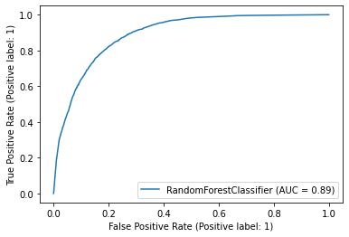

```python
rfc = RandomForestClassifier(criterion = "entropy",random_state = 1337,
                            oob_score = True)

# fit our model to the final splits
%time rfc.fit(X = fx_train, y = fy_train)
prte_rfc1 = rfc.predict(fx_test)

# get our results with some detailed info
print("Acc:", accuracy_score(y_true = fy_test, y_pred = prte_rfc1), "\n")
model_evaluation(actuals = fy_test, predictions = prte_rfc1)

print("Receiver Operating Characteristics:")
print("\nROC AUC score:\t", roc_auc_score(y_true = fy_test,
                                          y_score = prte_rfc1))
plot_roc_curve(estimator = rfc, X = fx_test, y = fy_test);
```

And versus LDA?

[output not shown]

|  | Predicted NO | Predicted YES |
| --- | --- | --- |
| Actual NO | 3067 | 2411 |
| Actual YES | 640 | 7103 |

```
Report:
              precision    recall  f1-score   support

           0       0.83      0.56      0.67      5478
           1       0.75      0.92      0.82      7743

    accuracy                           0.77     13221
   macro avg       0.79      0.74      0.75     13221
weighted avg       0.78      0.77      0.76     13221


Accuracy Score : 0.7692307692307693
-------------------------------------------------------------
Receiver Operating Characteristics:

ROC AUC score:	 0.7386102827710405
```

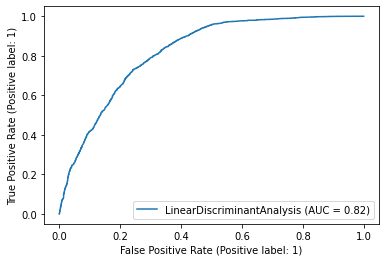

```python
# params won't change
gscv_lda_2 = GridSearchCV(estimator = lda,
                        param_grid = lda_params,
                        n_jobs = -3,
                        cv = 5,
                        scoring = "accuracy")

# fit it to our training data (the splits)
%time gscv_lda_2.fit(X = fx_train, y = fy_train)
lda_m2 = gscv_lda_2.best_estimator_
prte_lda2 = lda_m2.predict(fx_test)

# get our best performing model and format our split results
print("\n### GRID SEARCH: LINEAR DISCRIMINANT ANALYSIS ###")
print("-------------------------")
print("Best estimator:\t", lda_m2, "\nBest score:\t\t", gscv_lda_2.best_score_,
      "\t({:.2f}%)".format(gscv_lda_2.best_score_ * 100))
print("Accuracy test:\t", accuracy_score(fy_test, prte_lda2),
      "\t({:.2f}%)".format(accuracy_score(fy_test, prte_lda2) * 100))

# print some more detailed metrics to see how our model actually performed
print("\n")
model_evaluation(actuals = fy_test, predictions = prte_lda2)

print("Receiver Operating Characteristics:")
print("\nROC AUC score:\t", roc_auc_score(y_true = fy_test,
                                          y_score = prte_lda2))
plot_roc_curve(estimator = lda_m2, X = fx_test, y = fy_test);
```